# Comcast- Data Challenge

Gopalakrishnan Kalarikovilagam Subramanian

July 16, 2019

## INTRODUCTION

The dataset contains records of customer that were serviced by the CoE in the last 9 months, and the analyst created a binary indicator (1 = YES, 0 = NO) of which customers were cross-sold as the target variable.

The goal of this project is to build a model for detecting the dependencies of the output variable on a subset of the given input parameters. The data is a mixture of categorical and continuous variables.The data also contains many missing values. The data needs to be cleaned first. The dimentionality of the data set needs to be reduced to improve the ease of modelling, reduce the time of modelling and improve our understanding of the model.

The data set presents the transaction over 9 months and it has 300,000 observations. The output variable is “target” which is the response variable and can take value of 1 in case of success of cross-selling and 0 otherwise. The data set is highly unbalanced and therefore over-sampling technique has been used for improving the balance of the data set.

The output variable is binary and hence is a classification problem. Therefore the following methods can be used: 1. Logistic regression 2. Decision trees 3. Random Forest

## Packages Required

The following packages are being used for our analysis:

```r
#pretty doc to have a nice html output for the rmd
library(prettydoc)
library(dplyr)
library(rpart)
library(rpart.plot)
library(caret)
library(ranger)
library(pROC)
library(pdp)
library(ggplot2)
library(gbm)
library(xgboost)
library(adabag)
library(ROCR)
library(lattice)
library(randomForest)
```

## Data Collection

The data is imported into R work space. The delimitation used is ‘|’. The data consists of 300000 observations and 128 variables. The data is a mixture of categorical and continuous variables. The output variable is ‘target’ and is a binary variable which takes values ‘1’ and ‘0’.

## Data Preparation

The data set contains lots of NA value. To do feature engineering we need to have a clean data set without NA values. As a first step the variables having more than 5% NA values are removed. This resulted in the removal of 40 variables. The new data set contains 300000 observations and 88 variables. The rows are then scanned for NA values. Any row which contains a NA value is removed. This resulted in a new data set with 280427 rows.

```r
## Remove columns with more than 5% NA
Customer_data_mod <-  Customer_data[, -which(colMeans(is.na(Customer_data)) > 0.05)]

##Remove rows with NA values
Customer_data_mod2 <- Customer_data_mod[-which(rowMeans(is.na(Customer_data_mod)) > 0), ]
```

```r
#Variable correction

Customer_data_mod2$MAJOR_CREDIT_CARD_LIF <- ifelse(Customer_data_mod2$MAJOR_CREDIT_CARD_LIF == 'U', 1,0)

Customer_data_mod2$product <- ifelse(Customer_data_mod2$product == 'VIDEO/DATA/VOICE', 0,
                                         ifelse(Customer_data_mod2$product == 'VIDEO/DATA', 1,
                                                ifelse(Customer_data_mod2$product == 'DATA ONLY',2,
                                                       ifelse(Customer_data_mod2$product == 'VIDEO ONLY', 3,
                                                              ifelse(Customer_data_mod2$product == 'DATA/VOICE',4,
                                                                     ifelse(Customer_data_mod2$product == 'VIDEO/DATA/VOICE/HOME',5,6
                                                                            ))))))
```

### Feature Engineering

Feature Engineering is performed on the cleaned data set. The variables with zero variance are removed from the data set. This resulted in the removal of three variables. The data set is then split into two difference data frames - one with all the categorical variables and the other with all the continuous variables.

The continuous variables data set is then checked for near zero variance predictors. The split is done because the categorical variables are generally near zero predictors and would have been removed had this been done on the whole data frame. This necessitated the split into continuous and categorical data frames. The near zero variance test resulted in the removal of 29 variables.

```r
# Remove features with zero variance

Customer_data_mod2 <- Customer_data_mod2[ - as.numeric(which(apply(Customer_data_mod2, 2, var) == 0))]

#Seperate Categorical and Continuous variables

discreteL <- function(x) length(unique(x)) < 10

Customer_data_cont <- Customer_data_mod2[ , !sapply(Customer_data_mod2, discreteL)]
Customer_data_categorical <- Customer_data_mod2[ , sapply(Customer_data_mod2, discreteL)]


# Identify near zero variance predictors on the continuous data set

remove_cols <- nearZeroVar(Customer_data_cont, names = TRUE,
                           freqCut = 2, uniqueCut = 20)

# Get all column names from Customer_data_cont: all_cols

all_cols <- names(Customer_data_cont)

# Remove from data: Customer_data_cont2

Customer_data_cont2 <- Customer_data_cont[ , setdiff(all_cols, remove_cols)]
```

Pricipal component analysis is then performed on the reduced continuous dataframe. This is important because the regular principal component analysis can be carried on a continuous variable and this necessitated the orginal split into continuous and categorical data frames. The Principa component analysis resulted in the reduction of the 19 variables to 7 main principal components. These principal components explained 85% of the variance of the 19 variables. The individual eigen values of these 7 components are near the unity range and hence explain as much of the variance of a single normalized variable would. After the seventh principal compenent the eigen values are much lesser than 1 and it is neglected. The data frame containg these seven principal components are column binded with the categorical data frame created before and this is the reduced data frame which is going to be used for the data analysis.

The variables having maximum loading for Principal component 1 (PC1) are: AGE65_69(0.36), AGE60_64 (0.35), AGE70_74(0.34), AGE75_79(0.39), AGE30_34(-0.28). It mainly signifies people in the older age group.

The variables having maximum loading for Principal component 2 (PC2) are: AGE45_49(0.43), AGE50_54 (0.38), AGE40_44(0.31), AGE25_29(-0.32). This mainly signifies the middle age group.

The variables having maximum loading for Principal component 3 (PC3) are: AGE15_19(0.43), AGE21UP(-0.37), AGE35_39(-0.36), AGE40_44(-0.33), AGE30_34(-0.30). These might be the teanage boys who do not have brothers.

The variables having maximum loading for Principal component 4 (PC4) are: data_penetration_pct(0.61), video_penetration_pct(0.58). This principal component deals with the data penetration.

The variables having maximum loading for Principal component 5 (PC5) are: AGE20_24(-0.50), AGE18UP(0.40), AGE0_4(0.37). This principal component deals with the families with two kids. One who is toddler and the other at end of teenage.

The variables having maximum loading for Principal component 6 (PC6) are: bllng_amt(-0.99). This principal component gives a negative weightage to the billing amount.

The variables having maximum loading for Principal component 7 (PC7) are: AGE18UP(0.82), AGE0_4(-0.35), AGE20_24(0.29). This principal component deals with families with children in the age group 18-24, but do not have a toddler.

```r
#principal components analysis on the continuous variables

pZ <- prcomp(Customer_data_cont2, tol = 0.1, scale = TRUE)

PC_data_frame <- (cbind(pZ$x[,1], pZ$x[,2], pZ$x[,3], pZ$x[,4], pZ$x[,5], pZ$x[,6],
                        pZ$x[,7]))

colnames(PC_data_frame) <- c("PC1","PC2","PC3","PC4","PC5","PC6","PC7")

#Combining the categorical data frome and the PC data frame

Customer_data_corrected <- cbind(Customer_data_categorical,PC_data_frame)
```

## Exploratory Data Analysis

A plot of product and target is made. It is seen that when the product is ‘VIDEO/DATA’, there is a high positive target value. A relatively high proportion of target variable is positive when the product is ‘DATA ONLY. Very few target value is positive when the product is ’VIDEO/DATA/VOICE’.

A plot of previous number of products and the target variable is made. It is noticed that when the previous number of products is 1 or 2, there is a high chance of the target being successful. When it is three the chance of the customer buying the fourth product is miniscule.

A plot of the target variable and the customer previously having a voice product is made. It is seen that if the customer has a voice product before, he is not inclined to buying anything more.

When a customer is having previously a data product, he still goes for buying a new product. If the customer does not own a video product, he can be interested in buying a new product.

A plot of present product owned and previous voice product owner is made.It is noticed that some people with no voice connection before have taken it now as a ‘VIDEO/DATA/VOICE’ package. Very few peoplr have taken the ‘DATA/VOICE’ and ‘VIDEO/DATA/VOICE/HOME’ package. Most of the voice owners are in the ‘VIDEO/DATA/VOICE’ package.

A plot of present product owned and previous video data owner is made. Most of the previous video owner are in the ‘VIDEO/DATA/VOICE’ package, followed by ‘VIDEO/DATA’ package and then ‘VIDEO ONLY’’ package. A few people have joined these packages now.

A plot of count of prodcts used by customers is plotted. A large part of the customers are in the ‘VIDEO/DATA/VOICE’ package, followed by ‘VIDEO/DATA’, ‘DATA ONLY’ and ‘VIDEO ONLY’.

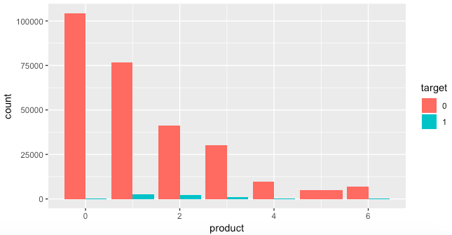

Variation of target across products

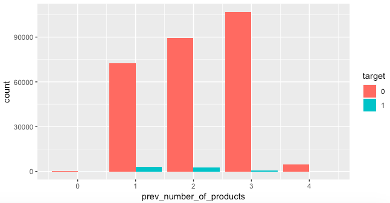

Variation of target across previous number of products

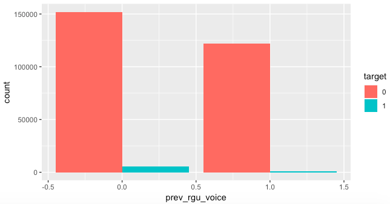

Variation of target across previous registered voice user

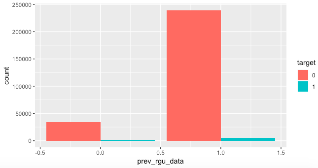

Variation of target across previous registered data user

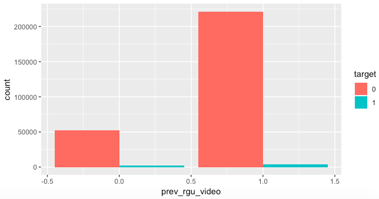

Variation of target across previous registered video user

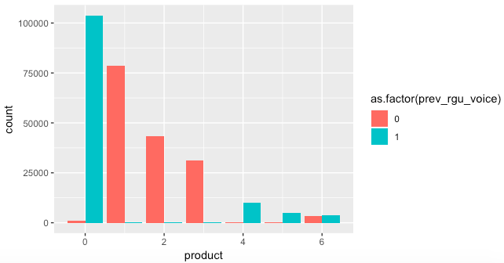

Variation of previous registered voice user across products

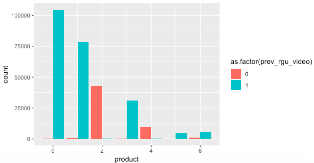

Variation of previous registered video user across products

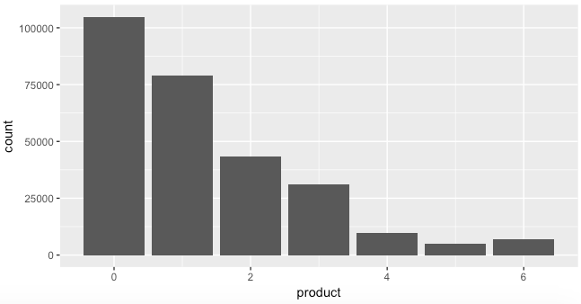

Number of different product users

## Over-Sampling

The dataframe is imbalanced. the number of 1’s and 0’s in the target variable is skewed. To Overcome this problem, ‘Over Sampling’ is done on the data set. In the Over-Sampling algorithm the data is separated on the basis of the target variable into two data sets. The data set containing the target variable in minority (i.e. in this case the data set containing the rows where target variable is 1) is added multiple times to the other data set. Multiple copies on the smaller data set is added to the bigger data set. This results in a new data set where is a balance in the observations with target variable as ‘0’ and ‘1’.

```r
#Oversampling the data

campaign_failure = Customer_data_corrected[Customer_data_corrected$target==0,]
campaign_sucess = Customer_data_corrected[Customer_data_corrected$target==1,]

new_data <- campaign_failure
for (i in 1:41)
{
  new_data <- rbind(new_data,campaign_sucess, deparse.level = 0, make.row.names = TRUE,
                    stringsAsFactors = default.stringsAsFactors())
}
table(new_data$target)
```

```r
# Partition the original_data into train/test sets
set.seed(1535)
index <- sample(nrow(Customer_data_corrected),nrow(Customer_data_corrected)*0.70)
train = Customer_data_corrected[index,]
test = Customer_data_corrected[-index,]

# Partition the Oversampled data set into train/test sets
set.seed(1535)
index <- sample(nrow(new_data),nrow(new_data)*0.60)
train_oversampled = new_data[index,]
test_oversampled = new_data[-index,]
```

## Data Modelling

### Decision Tree

```r
#Make the best tree model

target_rpart <- rpart(
  target ~ ., data = train_oversampled,
  control = list(cp = 0.00012), method = "class"
)
```

A similar prediction is carried out on the test data. The AUC value is 0.87 and the KS value is 0.66, which are very good. The gain chart shows a much smaller population range over which there are more positive responders. But the lift is almost 283.3% in this range which is excellent.

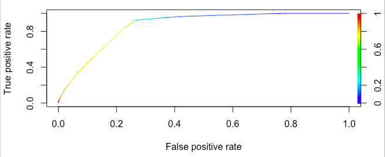

ROC curve for test data

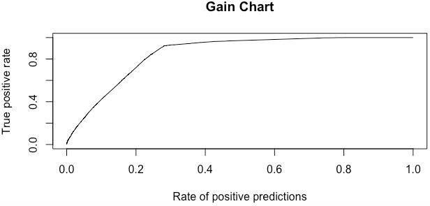

GAIN chart for test data

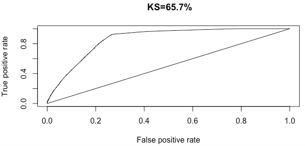

KS plot for test data

```r
#ROC Curve ,Gain Chart and K-S Chart for test data

target.test.random = predict(target_rpart,test, type="prob")
pred = prediction(target.test.random[,2], test$target)
perf = performance(pred, "tpr", "fpr")
plot(perf, colorize=TRUE)

slot(performance(pred, "auc"), "y.values")[[1]]

gain <- performance(pred, "tpr", "rpp")
plot(gain, main = "Gain Chart")

ks=max(attr(perf,'y.values')[[1]]-attr(perf,'x.values')[[1]])
plot(perf,main=paste0(' KS=',round(ks*100,1),'%'))
lines(x = c(0,1),y=c(0,1))
print(ks);

#Variable importance

target_rpart$variable.importance
```

The important variables used to build the tree are then studied. The top variables are product, prev_number_of_products, PC6, prev_rgu_voice, PC4, PC1, PC2, PC5, PC7, PC3, tellop_id.

It is seen that when the product is ‘VIDEO/DATA’,there is a high positive target value. A relatively high proportion of target variable is positive when the product is ‘DATA ONLY. Very few target value is positive when the product is ’VIDEO/DATA/VOICE’.

When the previous number products is 1 or 2 there is high chance of the target campaign being sucessful and when it is 3 the chances are miniscule.

The billing amount is an important predictor here for the targeting campaign. Next is the variable showing if the customer was previously using voice product. The next important variable is the data penetration(PC4). The next important variables are older age group(PC1) and middle aged group(PC2).

### Random Forest

```r
#Random Forest Model with 500 trees

target.rf <- randomForest(
target ~ .,
data = train_oversampled,
ntree = 500,
mtry = 8,
importance = FALSE
)
```

The model performs very well on the training data. The AUC is 0.99, which is the best possible ourput one can get. The KS value is 0.98, which again is very good.

A similar test is carried on the test data and the results are the same as the one with the training data. The gain chart a sharp slope, which means we can predict the exact percentage of the population who are going to give a positive response.

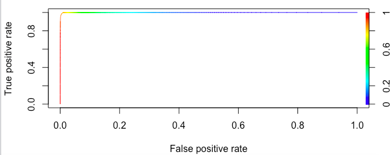

ROC curve for test data

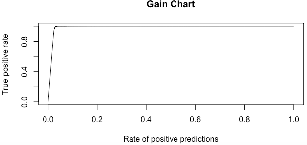

GAIN chart for test data

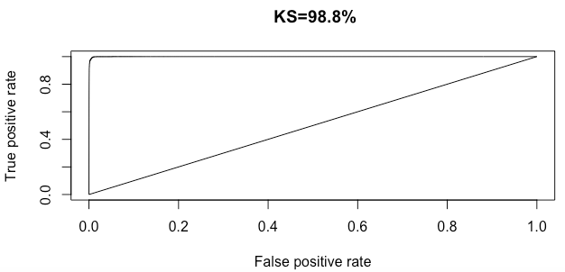

KS plot for test data

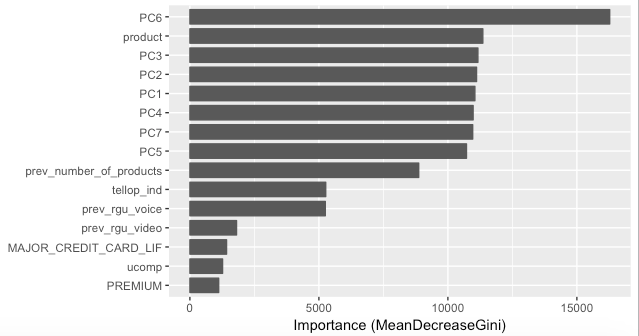

Variable Importance Prediction

```r
#ROC Curve ,Gain Chart and K-S Chart for test data

target.test.random = predict(target.rf,test, type="prob")
pred = prediction(target.test.random[,2], test$target)
perf = performance(pred, "tpr", "fpr")
plot(perf, colorize=TRUE)

slot(performance(pred, "auc"), "y.values")[[1]]

gain <- performance(pred, "tpr", "rpp")
plot(gain, main = "Gain Chart")

ks=max(attr(perf,'y.values')[[1]]-attr(perf,'x.values')[[1]])
plot(perf,main=paste0(' KS=',round(ks*100,1),'%'))
lines(x = c(0,1),y=c(0,1))
print(ks);

# Variable importance plot

vip::vip(target.rf, num_features = 15)
```

The most imporatant feature is the billing amount of the customer. A Customer with low billing amount will be a better target than a customer with a high billing amount.

A customer using the product ‘VIDEO/DATA’ and ‘DATA ONLY’ is a more likely target. A customer using the product ‘VIDEO/DATA/VOICE’ is a highly unlikely target.

### LOGISTIC REGRESSION

Logistic algorithm is then used to model the data. The imporatant variables from Random Forest Model is used to make the logistic regression. The important variables choosen are : PC6, PC3, product, PC2, PC4, PC1, PC7, PC5 and prev_number_of_products.

```r
# Logistic Regression model with most important variables from Random Forest Model

Customer.glm0<- glm(target~PC6+PC3+product+PC2+PC4+PC1+PC7+PC5+prev_number_of_products, family=binomial, data=train_oversampled)
summary(Customer.glm0)
```

## Summary

- The intial data contained 300,000 observations and 128 variables.
- The columns containing more than 5% NA values are removed.
- The rows containing NA values are removed.
- The zero variance variables are removed.
- The data-frame is then split into categorical and continuous variable dataframes.
- The continuous variable dataframe is cleaned of near-zero variance variables.
- Principal Component Analysis is performed on the cleaned continuous variable data-frame.
- The resulting seven PC variables are column binded with the categorical variables data-frame.
- Data-Frame split into training and testing data.
- Over-Sampling performed to valance the target outputs.
- Over-sampled data-frame split into training and test samples.
- Decision-Tree, Random-Forest and Logistic-Regression algorithms are used to model the training data.
- AUC values are used for comparing the models.
- Gain-Plots are created for the model to check the efficacy of the model to identify the target population.
- KS Chart are used for checking the capability of the model to split the positive and negative target outputs.